# Chiroptères forestiers

Boris Leroy

14/02/24

### *Note sur ce template Rmarkdown*

Ce fichier constitute un gabarit complet pour la modélisation des habitats potentiels d’une espèce ou d’un groupe d’espèce. Il est fourni sous licence libre CC-BY 4.0.

Il a été testé fonctionnel sur la version de R x86_64-w64-mingw32, x86_64, mingw32, ucrt, x86_64, mingw32, , 4, 3.2, 2023, 10, 31, 85441, R, R version 4.3.2 (2023-10-31 ucrt), Eye Holes, avec les packages sf (1.0.15), terra (1.7.71), ggplot2 (3.4.4), scales (1.3.0), egg (0.4.5), virtualspecies (1.6), blockCV (3.1.3), biomod2 (4.2.5), dplyr (1.1.4), tidyterra (0.5.2).

Il est possible que des évolutions futures de packages (notamment, biomod2, qui est sujet à de nombreuses évolutions en 2023 et 2024) rendent certaines parties du fichier non fonctionnelles, ce qui nécessitera de corriger le code.

# Pré-requis :

Chargement des packages et fonctions, chargement de données géographiques et des variables environnementales harmonisées

```r
library(sf)
library(terra)
library(ggplot2)
library(scales)
library(egg)
library(virtualspecies)
library(blockCV)
library(biomod2)
library(dplyr)
library(tidyterra)
source("scripts/functions.R")

# Shapefile de la Corse
corse <- st_read("data/corse.gpkg")
# Données environnementales harmonisées
env_corse <- rast("data/env_corse_total_sync.tif")
```

# Chargement et préparation des données d’occurrence

```r
chiroforet <- st_read("data/donnees_brutes/taxa/Chiro_forestier.shp")
```

```
## replacing null geometries with empty geometries
## Simple feature collection with 15400 features and 69 fields (with 27 geometries empty)
## Geometry type: POINT
## Dimension:     XY
## Bounding box:  xmin: 8.544579 ymin: 41.37692 xmax: 9.546355 ymax: 43.02367
## Geodetic CRS:  WGS 84
```

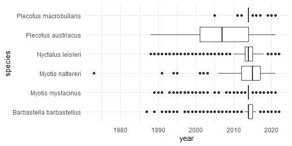

```r
# Simplification du nom d'espèce en binomial
chiroforet$species <- simplify_species_name(chiroforet$nom_valide)
# Retrait d'une araignée qui s'est glissée par erreur dans le groupe des
# chiroptères
chiroforet <- chiroforet[-which(chiroforet$species %in%
                                  "Enoplognatha thoracica"), ]

# Dates d'échantillonnage
chiroforet$year <- as.numeric(strtrim(chiroforet$date_fin, 4))
chiroforet$month <- as.numeric(substr(chiroforet$date_fin, 6, 7))

# Visualisation de la temporalité des occurrences
ggplot(chiroforet) +
  geom_boxplot(aes(x = species,
                   y = year))+
  coord_flip() +
  scale_y_continuous(breaks = breaks_pretty()) +
  theme_minimal()
```

## Filtre temporel

Les espèces présentent une saisonnalité forte ; nous ne modéliserons ici que les habitats de la période estivale pour laquelle il existe suffisamment de données. Le Groupe Chiroptères Corses suggère une temporalité allant du 15 mai au 15 septembre ; nous ne retiendrons donc que les données des mois de mai à septembre.

```r
chiroforet <- chiroforet[chiroforet$month >= 5 &
                             chiroforet$month <= 9, ]
```

Il faut établir un filtre temporel pour éliminer les données imprécises, sachant que l’objectif est de modéliser à une résolution assez fine, de l’ordre de 1km. Le champ `precision` est peu renseigné et donc peu utile ici, il nous faut donc poser une hypothèse sur les données qui sont imprécises. On peut considérer que les GPS ont commencé à être largement disponibles à partir de 1990, mais leur utilisation ne s’est généralisée qu’à partir des années 2000, notamment grâce à leur miniaturisation. Ainsi, on peut spéculer qu’avant les années 2000, les données étaient moins précisés car possiblement géolocalisées en utilisant des référentiels comme les lieu-dits ou les communes, tandis qu’à partir des années 2000 la précision s’est améliorée grâce à la géolocalisation par satellite.

Le nombre de données supprimées en fixant un seuil à l’année 2000 est très faible :

```r
# Les données avant 2000 représentent un % modéré du jeu de données :
100 * length(which(chiroforet$year < 2000)) / nrow(chiroforet)
```

```
## [1] 3.967351
```

La couverture temporelle sur l’année est plus complète après 2000 :

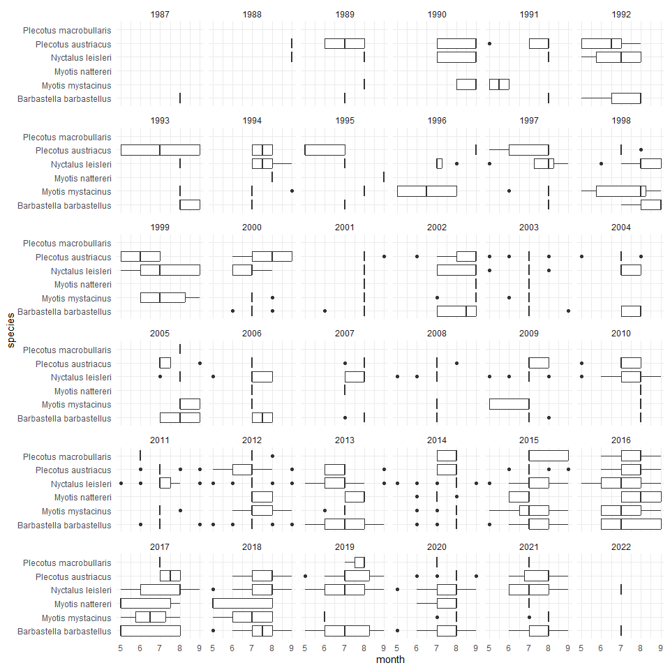

```r
ggplot(chiroforet) +
  geom_boxplot(aes(x = species,
                   y = month)) +
  facet_wrap(~year) +
  coord_flip() +
  scale_y_continuous(breaks = breaks_pretty()) +
  theme_minimal()
```

L’emprise spatiale des données d’occurrence ne change pas de manière majeure avec ou sans les données pré-2000 :

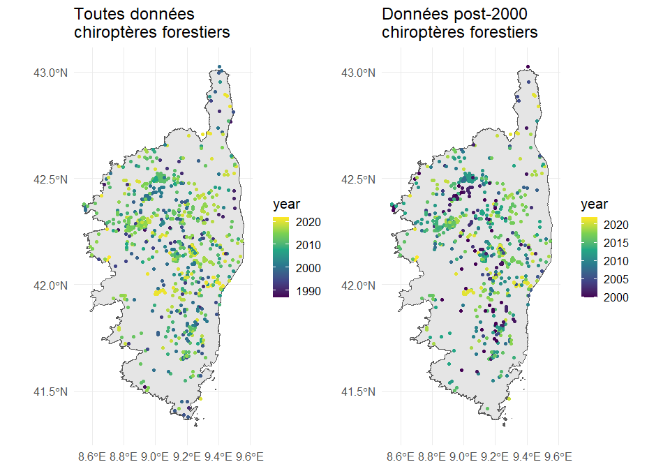

```r
p_chiroforet_all <- ggplot() +
  geom_sf(data = corse) +
  geom_sf(data = chiroforet, aes(col = year)) +
  scale_color_continuous(type = "viridis") +
  theme_minimal(base_size = 15) +
  ggtitle("Toutes données\nchiroptères forestiers")

p_chiroforet_post2000 <- ggplot() +
  geom_sf(data = corse) +
  geom_sf(data = chiroforet[chiroforet$year >= 2000, ], aes(col = year)) +
  scale_color_continuous(type = "viridis") +
  theme_minimal(base_size = 15) +
  ggtitle("Données post-2000\nchiroptères forestiers")

ggarrange(p_chiroforet_all,
          p_chiroforet_post2000,
          nrow = 1)
```

On pose donc l’hypothèse raisonnable qu’un filtre à 2000 va assurer une bonne précision dans la localisation des occurrences sans perdre d’information critique sur la répartition des espèces.

```r
chiroforet <- chiroforet[which(chiroforet$year >= 2000), ]
```

## Rasterisation des occurrences

L’objectif ici est de ne garder qu’une occurrence par cellule à la résolution de nos variables environnementales afin d’éviter une forme extrême de pseudo-réplication.

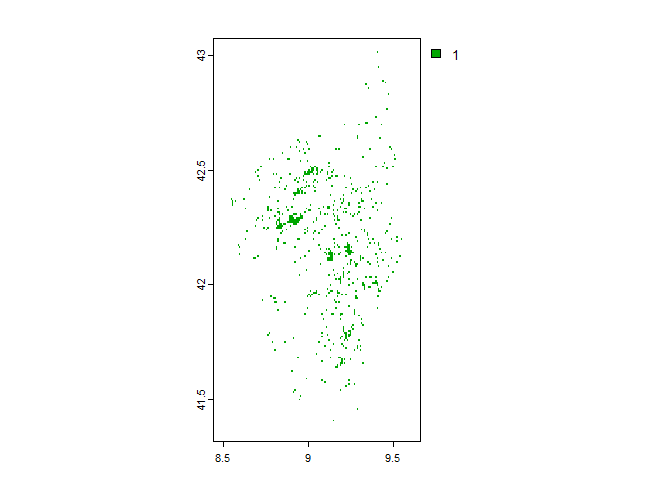

```r
# On rasterise les occurrences à la résolution de nos variables
# environnementales
chiroforet_r <- rasterize(chiroforet,
                      env_corse)
names(chiroforet_r) <- "chiroforet"

plot(chiroforet_r)
```

On va ensuite éliminer les occurrence qui sont dans des zones sans valeurs de variables environnementales. Pour cela on va combiner les variables environnementales avec les occurrences rasterisées dans un `data.frame`, et supprimer les occurrences d’espèces qui tombent sur des données environnementales manquantes

```r
# On crée un stack avec nos occurrences rasterisées et les variables env
env_chiroforet <- c(env_corse,
                     chiroforet_r)

# On récupère les coordonnées XY de toutes les cellules, pour préparer nos
# données finales
coorXY <- xyFromCell(env_corse,
                     1:ncell(env_corse))
# On transforme le raster en data.frame
env_chiroforet_df <- values(env_chiroforet)

# On regarde le nombre d'occurrences pour lesquelles il y a des données
# manquantes :
length(which(is.na(env_chiroforet_df[, "bio1"]) &
               !is.na(env_chiroforet_df[, "chiroforet"])))
```

```
## [1] 9
```

On va maintenant supprimer les cellules pour lesquelles on n’a pas de données environnementales. Pour cela on va utiliser la première variable environnementale ici, car les données manquantes sont toutes les mêmes entre toutes les variables environnementales (cf. script harmonisation des données).

```r
# On filtre d'abord sur l'objet qui contient les coordonnées
coorXY <- coorXY[-which(is.na(env_chiroforet_df[, 1])), ]
# Et ensuite sur le tableau avec variables env et présences d'espèces
env_chiroforet_df <- env_chiroforet_df[-which(is.na(env_chiroforet_df[, 1])), ]

# Comparaison du nombre d'occurrences :
# Avant rasterisation
nrow(chiroforet)
```

```
## [1] 14354
```

```r
# Après rasterisation et élimination des données env manquantes
length(which(env_chiroforet_df[, "chiroforet"] == 1))
```

```
## [1] 623
```

Il s’agit donc du nombre d’occurrences que l’on va pouvoir utiliser pour calibrer nos modèles. On va maintenant formater ces occurrences en combinant coordonnées et info sur l’occurrence dans un `data.frame` pour préparer la calibration de nos modèles

```r
P_points <- data.frame(
  # D'abord on récupère les coordonnées XY qui correspondent à nos cellules de présences
  coorXY[which(!is.na(env_chiroforet_df[, "chiroforet"])), ],
  # Ensuite, on récupère la colonne qui indique présence pour chaque cellule
  occurrence = env_chiroforet_df[which(!is.na(env_chiroforet_df[, "chiroforet"])),
                             "chiroforet"])

P_points
```

| x | y | occurrence |
| --- | --- | --- |
| 9.412360 | 42.95403 | 1 |
| 9.437360 | 42.89569 | 1 |
| 9.454027 | 42.88736 | 1 |
| 9.337360 | 42.87903 | 1 |
| 9.354027 | 42.86236 | 1 |
| 9.470694 | 42.83736 | 1 |
| 9.462360 | 42.77069 | 1 |
| 9.395694 | 42.73736 | 1 |
| 9.337360 | 42.71236 | 1 |
| 9.345694 | 42.71236 | 1 |

[output cut: 613 more lines]

# Génération des points de background

La littérature statistique récente suggère que les meilleures pratiques consistent à générer un grand nombre de points de background (e.g., 10000) indépendamment de la localisation des points de présence (i.e., un point de background peut être localisé au même endroit qu’un point de présence). Cela permet d’assurer une bonne représentation de l’ensemble des conditions environnementales disponibles dans le modèle. Dans le cas de la Corse, le nombre de points de background sera limité par le nombre de pixels disponibles :

```r
# Nous avons éliminé les données manquantes du tableau env_amphib_df
# Par conséquent, son nombre de lignes est égal au nombre total de pixels
# disponibles sur la Corse
nrow(env_chiroforet_df)
```

```
## [1] 13620
```

Des tests préliminaires ont montré que la distance aux routes joue très fortement sur les résultats des modèles, donc nous intégrons directement le biais dans la génération des backgrounds, ce qui est plus efficace que de l’inclure en variable explicative.

```r
prob_distance_routes <- env_corse[["distance_routes"]]
# Utilisation d'une exponentielle inverse pour la probabilité d'échantillonnage

prob_distance_routes <-
  exp(-(prob_distance_routes / global(prob_distance_routes,
                                      "max", na.rm = T)[1, 1] + 1)^2)

# On réduit également le nombre de background pour avoir un effet du biais
background <- spatSample(prob_distance_routes,
                         method = "weights",
                         size = 5000,
                         replace = FALSE, # Pas de remise
                         na.rm = TRUE, # Pas dans les données manquantes
                         xy = TRUE, # L'output inclut les coords XY
                         values = FALSE) # L'output exclut les variables

# background <- spatSample(env_corse,
#                          size = 10000,
#                          replace = FALSE, # Pas de remise
#                          na.rm = TRUE, # Pas dans les données manquantes
#                          xy = TRUE, # L'output inclut les coords XY
#                          values = FALSE) # L'output exclut les variables


# On ajoute les points de background aux données de présence
P_points <- rbind.data.frame(P_points,
                             data.frame(background,
                                        occurrence = 0))
```

# Sélection des variables environnementales

## Climat

Les chauves-souris sont dépendantes des conditions climatologiques pour la sélection de leurs abris et sites de nichage et pour leur activité. Les études macroécologiques suggèrent que les chiroptères préfèrent des températures douces à chaudes et un degré d’humidité élevé (McCain 2007), et les variables de température et de précipitation sont systématiquement utilisées comme des prédicteurs pertinents dans les modèles de distribution de chiroptères. Nous utiliserons donc des variables reflétant les limites potentielles qui empêchent l’occurrence des chiroptères, avec l’hypothèse que les espèces préfèrent des conditions intermédiaires, douces et humides : effet limitant des températures trop froides ou trop chaudes (températures les plus chaudes et les plus froides de l’année), effet limitant de l’humidité relative (humidité relative minimale et maximale).

Noms des variables retenues :

- températures les plus chaudes de l’année (*bio5*)
- températures les plus froides sur la saison estivale (*tasmin_chiro*)
- humidité relative minimale (*cmi_min*) et maximale (*cmi_max*).

## Occupation du sol

Les chiroptères forestiers vivent et nichent dans les forêts en utilisant notamment les anfractuosités du bois mort. Ainsi, s’il est attendu que ces espèces dépendent des forêts, il est fort probable que toutes les forêts ne permettent pas de leur offrir un habitat réellement favorable (Miller et al. 2003). Par exemple, les forêts gérées dans lesquelles les arbres morts ne sont pas laissés sur pied ou les forêts de plantation monospécifiques avec une rotation de coupe relativement courte ne permettent probablement pas d’avoir les conditions de microhabitat requises pour la plupart des chiroptères forestiers. Ainsi, il apparait nécessaire d’effectuer une distinction dans le type de couvert forestier pour identifier plus clairement les habitats favorables aux chiroptères forestiers. Une problématique majeure ici est qu’il est probable qu’il y ait un décalage temporel entre l’occurrence d’observation de l’espèce et les variables spatialisées de couvert forestier dont nous disposons. Nous nous efforcerons donc d’explorer l’effet du couvert forestier sur la probabilité d’observation en distinguant au mieux les forêts non gérées ou gérées de manière favorable aux chauves-souris. Cependant, il est à attendre un fort degré d’incertitude qui peut rendre la relation moins nette ou moins évidente, à la fois à cause de l’incertitude sur la nature de la gestion des forêts et sur le décalage temporel entre moment d’observation de l’espèce et date des couches géographiques d’occupation du sol. Nous utiliserons la variable d’intégrité biophysique des sols comme indicateur de la probabilité d’exploitation forestière, car l’exploitation forestière fait partie intégrante du calcul de de l’indice d’intégrité biophysique des sols (Guetté et al. 2021).

Par ailleurs, comme pour les autres types de chiroptères, nous explorerons l’effet de la distance aux zones humides et de la diversité d’occupation du sol, en supposant un effet positif a priori ; nous étudierons également l’effet de la distance aux cavités, car celles-ci peuvent également abriter les différentes espèces de ce groupe.

Enfin, la connectivité peut beaucoup jouer sur la présence des chauves-souris en leur permettant de se déplacer ; nous utiliserons donc la variable de continuité spatiale développée par l’IUCN (Guetté et al. 2021) en supposant un effet positif de la connectivité sur la probabilité d’observer les espèces.

Noms des variables retenues :

- couvert forestier (*forets*)
- distance aux forêts (*dist_forets*)
- intégrité biophysique des sols (*integrite*)
- distance aux zones humides (*dist_moy_pzh*)
- homogénéisation du paysage (*simpson_landscapediv*)
- connectivité (*connectivite*)

## Biais d’échantillonnage

La probabilité d’observer les espèces est souvent directement liée à l’accessibilité du milieu, qui est connue pour être fortement corrélée à la distance aux routes. Nous utiliserons donc la distance aux routes comme proxy du biais d’échantillonnage afin d’éviter que les modèles ne cherchent à expliquer l’accessibilité par les autres variables environnementales.

Noms des variables retenues :

- distance aux routes (*distance_routes*)

## Variables anthropogéniques

La pollution lumineuse affecte de manière différente les chauves-souris : certaines espèces sont très négativement impactées, tandis que d’autres y semblent insensibles voire en bénéficient (Azam et al. 2016). Si nous ne disposons pas de données sur la pollution lumineuse, nous pouvons néanmoins hypothétiser que la densité de population humaine ou que la tâche urbaine sont corrélées à la pollution lumineuse, avec un autre effet négatif corrélé qui est la densité de surfaces artificielles. Ainsi, nous testerons s’il existe un effet négatif des surfaces artificielles sur la probabilité d’observation des chiroptères. Néanmoins, pour ce groupe un effet positif peut s’opposer à cette hypothèse, car certaines des espèces sont connues pour occuper des habitats artificiels (e.g., *Barbastella barbastellus*), ce qui peut créer une effet favorable de l’emprise urbaine. Dans ce cas, la relation entre variables densité de population humaine ou tâche urbaine risque d’être complexe (e.g., effet positif à densité faible puis négatif à densité forte).

Noms des variables retenues :

- pollution lumineuse (*pollum*)
- zones artificielles (*zones_artif*)

## Autres variables et commentaires

Les chauves-souris régissent leur activité en fonction du vent, préférant les périodes où le vent est faible (Barré et al. 2023). Ainsi, il est attendu qu’elles aient moins de chance d’occuper les zones fortement ventées ou sujettes aux rafales excessives. Nous testerons donc s’il existe un effet négatif des variables correspondant aux vitesses de vent.

Noms des variables retenues :

- Vitesse du vent mensualisée maximale sur l’année (*sfcWind_max*)

## Constitution du jeu de variables finales pour les chiroptères forestiers

### Préparation des rasters

```r
env_chiroforet <- env_corse[[c("bio5",
                               "tasmin_chiro",
                               "cmi_min",
                               "cmi_max",
                               "forets",
                               "dist_forets",
                               "dist_moy_pzh",
                               "pollum",
                               "zones_artif",
                               "sfcWind_max",
                               "integrite",
                               "simpson_landscapediv",
                               "connectivite")]]
```

### Etude de la colinéarité et réduction du nombre de variables

On étudie la colinéarité entre les variables avec le coefficient de corrélation de Spearman (car certaines variables ne sont pas distribuées normalement), en utilisant un seuil standard de 0.7.

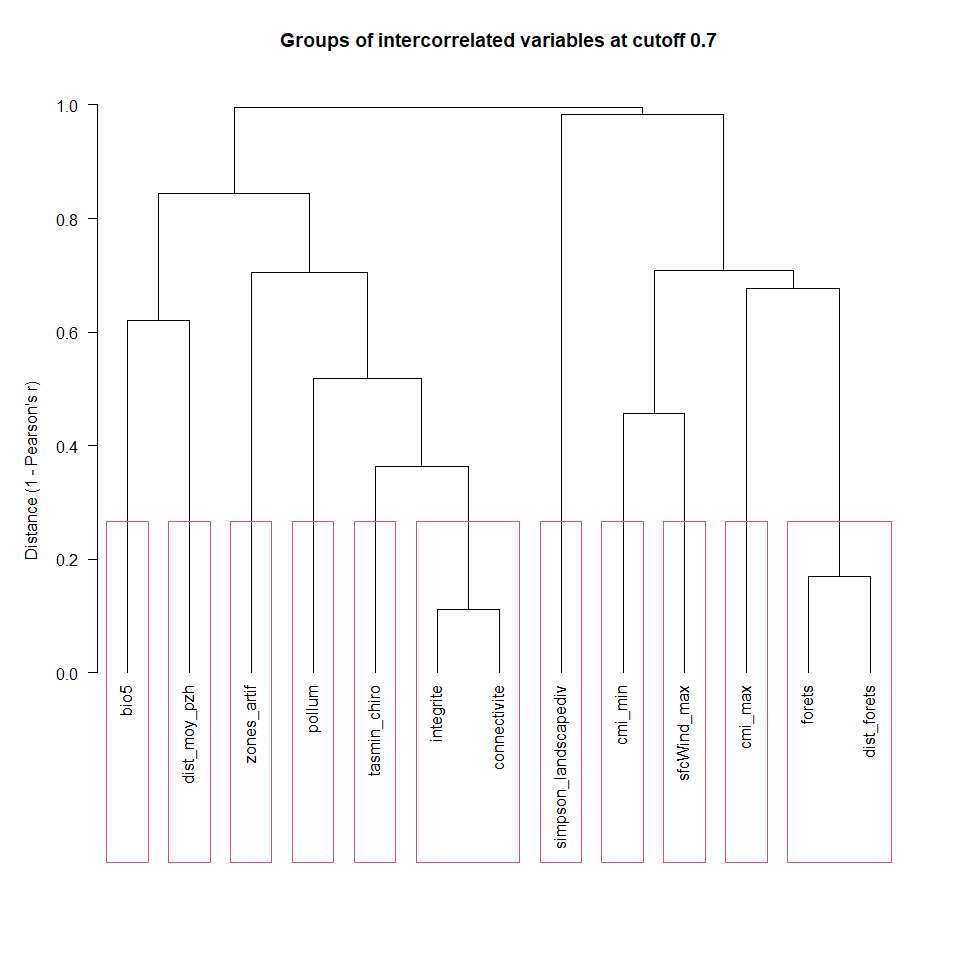

```r
# Modifier pour les corrélations 2 à 2 ? e.g. corrplot?
var_groups <- removeCollinearity(env_chiroforet,
                                 plot = TRUE,
                                 multicollinearity.cutoff = 0.7,
                                 method = "spearman")
```

Deux jeux de variables sont corrélées fortement : intégrité et connectivité ; couvert forestier et distance aux forêts. Nous conserverons ici l’intégrité plutôt que la connectivité, et le couvert forestier plutôt que la distance aux forêts.

```r
env_chiroforet <- env_chiroforet[[-which(names(env_chiroforet) ==
                                             "connectivite")]]
env_chiroforet <- env_chiroforet[[-which(names(env_chiroforet) ==
                                             "dist_forets")]]
```

Au total cela fait 11 variables environnementales, ce qui peut être excessif pour les modèles et créer un risque d’overfitting. Nous allons donc réduire le nombre de variables à 10, en supprimant les zones artificielles car l’hypothèse liée à cette variable est la plus faible, et les effets des zones artificielles sont probablement inclus dans la pollution lumineuse et l’intégrité biophysique des sols.

```r
env_chiroforet <- env_chiroforet[[-which(names(env_chiroforet) ==
                                             "zones_artif")]]
```

# Préparation de la stratégie de validation croisée des modèles

Nous allons utiliser une procédure de validation croisée par bloc ce qui permet de réduire l’autocorrélation spatiale entre jeu de données de calibration et jeu de validation.

## Définition de la taille des blocs

Il faut étudier le degré d’autocorrélation spatiale dans les variables environnementales pour avoir une idée de la taille des blocs. La taille des blocs est un compromis entre la diminution de l’autocorrélation spatiale et les contraintes des données.

```r
# Pour étudier la taille des blocs à viser, il faut d'abord projeter le raster
env_chiroforet_l93 <- project(env_chiroforet,
                               "EPSG:2154")

# Ensuite on étudie le range d'autocorrélation spatiale
AC_range <- cv_spatial_autocor(env_chiroforet_l93)
```

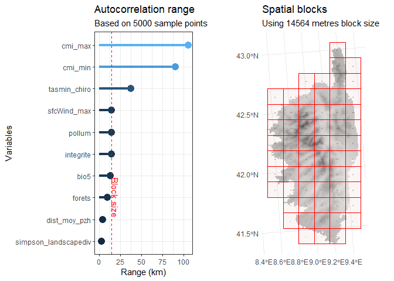

On obtient un range médian qui est de 1.4563727^{4}, ce qui est satisfaisant ici pour réaliser une validation croisée par blocs : il y a beaucoup de blocs, ce qui signifie que la répartition des blocs en plis sera probablement bien équilibrée.

```r
P_points_sf <- st_as_sf(P_points,
                        coords = c("x", "y"),
                        crs = "EPSG:4326")

plis_cv <- cv_spatial(x = P_points_sf,
                      column = "occurrence", # Nom de la colonne des occurrences
                      k = 5, # Nombre de plis (folds) pour la k-fold CV
                      size = AC_range$range, # Taille des blocs en metres
                      selection = "random", # Attribution des blocs aléatoire dans
                      # les plis
                      iteration = 50, # Nombre d'essais pour trouver des plis
                      # équilibrés
                      biomod2 = TRUE, # Formater les données pour biomod2
                      r = env_chiroforet, # Pour le fond de carte
                      progress = FALSE)
```

```
##
##   train_0 train_1 test_0 test_1
## 1    4017     512    983    111
## 2    3968     491   1032    132
## 3    3983     521   1017    102
## 4    4067     502    933    121
## 5    3965     466   1035    157
```

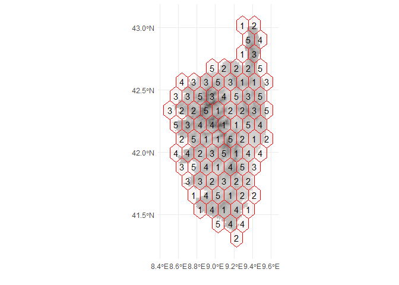

On voit que nos plis sont plutôt bien équilibrés, avec environ 500 présences en moyenne pour la calibration, et de environ 120 présences pour l’évaluation, ce qui est correct.

Dernière étape, biomod2 exige un format particulier pour les plis de validation croisée, donc on va préparer ce format ici :

```r
table_cv <- plis_cv$biomod_table
colnames(table_cv) <- paste0("_allData_",
                             colnames(table_cv))
```

# Calibration des modèles

Tout d’abord on prépare les données pour biomod2.

```r
coorxy <- P_points[, c("x", "y")]
occurrences <- P_points[, "occurrence"]


dir.create("models/chiroforet", recursive = T, showWarnings = FALSE)

run_data <- BIOMOD_FormatingData(
  resp.name = "chiroforet", # Nom de l'espèce
  resp.var = occurrences, # Présences + background
  expl.var = env_chiroforet, # Variables environnementales prédictives
  dir.name = "models", # Dossier dans lequel on va stocker les modèles
  resp.xy = coorxy, # Coordonnées xy des présences et background
  PA.strategy = NULL) # Pas de génération de points de background par biomod
```

```
##
## -=-=-=-=-=-=-=-=-=-=-=-=-= chiroforet Data Formating -=-=-=-=-=-=-=-=-=-=-=-=-=
##
##       ! No data has been set aside for modeling evaluation
##       ! No data has been set aside for modeling evaluation
##  !!! Some data are located in the same raster cell.
##           Please set `filter.raster = TRUE` if you want an automatic filtering.
##       ! No data has been set aside for modeling evaluation
## -=-=-=-=-=-=-=-=-=-=-=-=-=-=-=-=-=-= Done -=-=-=-=-=-=-=-=-=-=-=-=-=-=-=-=-=-=
```

```r
# Car on en a généré nous-mêmes

saveRDS(run_data, file = paste0("models/chiroforet/run_data.RDS"))
```

Biomod nous indique deux choses : que nous n’avons pas de données indépendantes pour l’évaluation, ce qui est effectivement le cas à ce stade de l’étude. Par ailleurs, que plusieurs données peuvent être dans la même cellule, ce qui est également attendu car nous avons tiré aléatoirement nos background dans toute la zone d’étude et donc ils ont pu tomber dans les mêmes cellules que des points de présence. Pas d’inquiétudes, c’est ce que l’on avait prévu.

La solution pour bien paramétrer les modèles face au déséquilibre et au chevauchement varie selon les modèles, mais le principe général est de réduire l’importance des backgrounds lors de la calibration par rapport au présence, afin de viser un ratio équilibre 50/50 entre importance des présences et importance des backgrounds. Par exemple, on va attribuer des poids aux présences et aux backgrounds de sorte que la somme du poids des présences et des backgrounds soit égale. Cependant, cette méthode fonctionne mal sur certains modèles comme le random forest, et il faut alors le paramétrer de manière plus fine avec un rééchantillonnage à 50/50 en interne.

Par ailleurs, il est important de noter que l’évaluation des modèles avec la validation croisée n’est pas un élément validant la robustesse du modèle. Elle est plutôt à considérer comme un élément qui élimine les mauvais modèles, mais elle ne constitute pas une preuve de robustesse quand elle est bonne, car elle est limitée à la fois par la nature des données (présence-seule, pas d’absences), et par la possibilité qu’il y ait des biais dans l’échantillonnage. Ainsi, il est difficile d’utiliser la validation croisée pour identifier les meilleurs modèles ; il vaut mieux donc se baser sur des paramètres établis pour être robustes en situation de présence-seule (e.g., Valavi et al. 2021).

Préparons donc la calibration de nos modèles :

```r
calib_summary <-
  summary(run_data, calib.lines =  table_cv) %>%
  filter(dataset == "calibration")

iwp <- (10^6)^(1 - occurrences)


RF_param_list <- NULL
GLM_param_list <- NULL
GBM_param_list <- NULL
XGBOOST_param_list <- NULL
XGBOOST_param_list <- NULL
GAM_param_list <- NULL
MARS_param_list <- NULL
XGBOOST_param_list <- NULL
for (cvrun in 1:nrow(calib_summary)) {

  prNum <- calib_summary$Presences[cvrun]
  bgNum <- calib_summary$True_Absences[cvrun]

  wt <- ifelse(occurrences == 1, 1, prNum / bgNum)

  RF_param_list[[paste0("_",
                        calib_summary$PA[[cvrun]],
                        "_",
                        calib_summary$run[[cvrun]])]] <-
    list(ntree = 1000,
         sampsize =  c("0" = prNum,
                       "1" = prNum),
         replace = TRUE)

  GLM_param_list[[paste0("_",
                         calib_summary$PA[[cvrun]],
                         "_",
                         calib_summary$run[[cvrun]])]] <-
    list(weights = wt)


  GBM_param_list[[paste0("_",
                         calib_summary$PA[[cvrun]],
                         "_",
                         calib_summary$run[[cvrun]])]] <-
    list(interaction.depth = 5,
         n.trees = 5000,
         shrinkage = 0.001,
         bag.fraction = 0.75,
         cv.folds = 5,
         weights = wt)

  GAM_param_list[[paste0("_",
                         calib_summary$PA[[cvrun]],
                         "_",
                         calib_summary$run[[cvrun]])]] <-
    list(weights = wt,
         method = "REML")

  MARS_param_list[[paste0("_",
                          calib_summary$PA[[cvrun]],
                          "_",
                          calib_summary$run[[cvrun]])]] <-
    list(weights = wt)

  XGBOOST_param_list[[paste0("_",
                             calib_summary$PA[[cvrun]],
                             "_",
                             calib_summary$run[[cvrun]])]] <-
    list(nrounds = 10000,
         eta = 0.001,
         max_depth = 5,
         subsample = 0.75,
         gamma = 0,
         colsample_bytree = 0.8,
         min_child_weight = 1,
         weight = wt,
         verbose = 0)
}

model_parameters <- bm_ModelingOptions(
  data.type = "binary",
  models = c("GLM", "GBM", "GAM.mgcv.gam", "MARS", "RF", "MAXNET", "XGBOOST"),
  strategy = "user.defined",
  user.base = "default",
  user.val = list(
    GLM.binary.stats.glm = GLM_param_list,
    GBM.binary.gbm.gbm = GBM_param_list,
    GAM.binary.mgcv.gam = GAM_param_list,
    MARS.binary.earth.earth = MARS_param_list,
    RF.binary.randomForest.randomForest = RF_param_list,
    XGBOOST.binary.xgboost.xgboost = XGBOOST_param_list
  ),
  bm.format = run_data,
  calib.lines = table_cv
)
```

```
##
## -=-=-=-=-=-=-=-=-=-=-=-=-=-= Build Modeling Options -=-=-=-=-=-=-=-=-=-=-=-=-=-=
##
##  >  GLM options (datatype: binary , package: stats , function: glm )...
##  >  GBM options (datatype: binary , package: gbm , function: gbm )...
##  >  GAM options (datatype: binary , package: mgcv , function: gam )...
##  >  MARS options (datatype: binary , package: earth , function: earth )...
##  >  RF options (datatype: binary , package: randomForest , function: randomForest )...
##  >  MAXNET options (datatype: binary , package: maxnet , function: maxnet )...
##  >  XGBOOST options (datatype: binary , package: xgboost , function: xgboost )...
##
## -=-=-=-=-=-=-=-=-=-=-=-=-=-=-=-=-=-= Done -=-=-=-=-=-=-=-=-=-=-=-=-=-=-=-=-=-=
```

```r
model_runs <- BIOMOD_Modeling(
  run_data,
  modeling.id = "1", # ID de modélisation, on met 1 pour tous nos modèles ici
  models = c("GLM", "GBM", "GAM",  "MARS",
             "MAXNET", "RF", "XGBOOST"),
  OPT.strategy = "user.defined",
  OPT.user = model_parameters, # Paramètres des modèles
  CV.strategy = "user.defined", # Méthode de validation croisée
  CV.user.table = table_cv, # Plis générés précéemment
  CV.do.full.models = FALSE,
  var.import = 10, # Nombre de répétitions d'importance des variables
  metric.eval = "BOYCE",
  do.progress = FALSE,
  nb.cpu = 16 # Nombre de coeurs à utiliser pour la modélisation
  # A ajuster selon votre ordinateur, ne pas en mettre trop !
)
saveRDS(model_runs, file = "models/chiroforet/model_runs.RDS")
```

# Evaluation des modèles

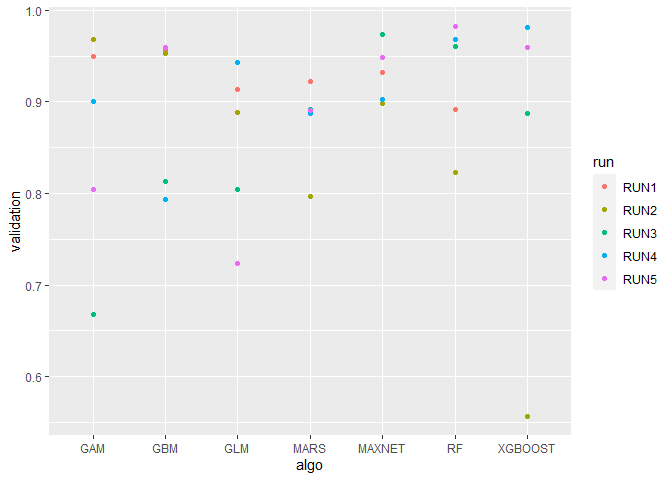

```r
evals_boyce <- get_evaluations(model_runs)
ggplot(evals_boyce, aes(x = algo, y = validation)) +
  geom_point(aes(col = run))
```

# Importance des variables

```r
varimp <- get_variables_importance(model_runs)

varimp$expl.var <- reorder(varimp$expl.var,
                           varimp$var.imp,
                           median,
                           na.rm = TRUE)



varimp %>%
  group_by(expl.var) %>%
  summarise(median = median(var.imp))
```

| expl.var | median |
| --- | --- |
| integrite | 0.0185765 |
| cmi_min | 0.0299945 |
| sfcWind_max | 0.0415125 |
| simpson_landscapediv | 0.0518335 |
| cmi_max | 0.0566485 |
| bio5 | 0.0741845 |
| forets | 0.0773125 |
| dist_moy_pzh | 0.0843755 |
| pollum | 0.1132465 |
| tasmin_chiro | 0.4270070 |

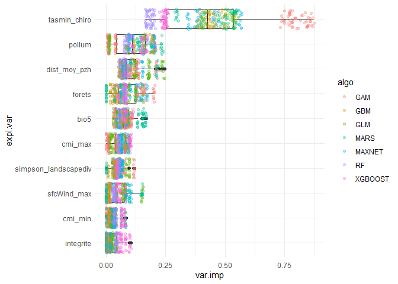

```r
ggplot(varimp) +
  geom_boxplot(aes(x = expl.var, y = var.imp)) +
  geom_jitter(aes(x = expl.var, y = var.imp, col = algo),
              alpha = .3) +
  coord_flip() +
  theme_minimal()
```

# Courbes de réponse

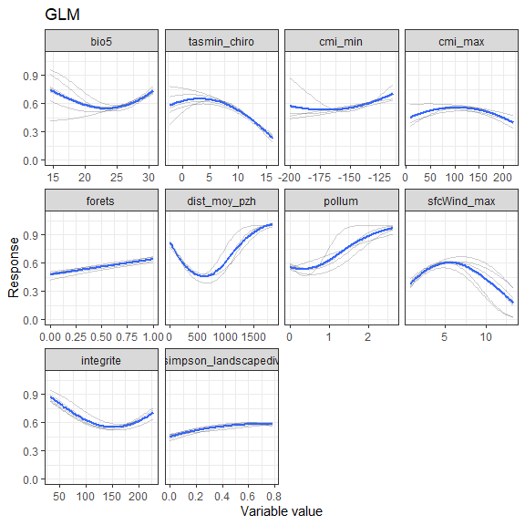

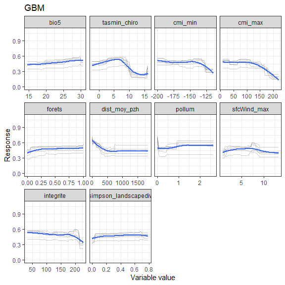

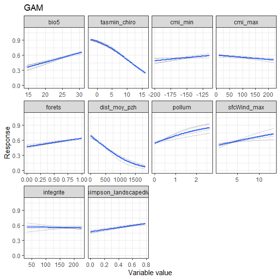

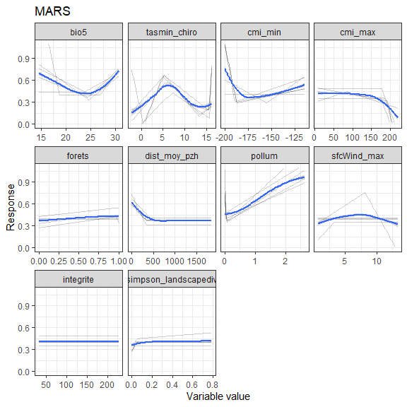

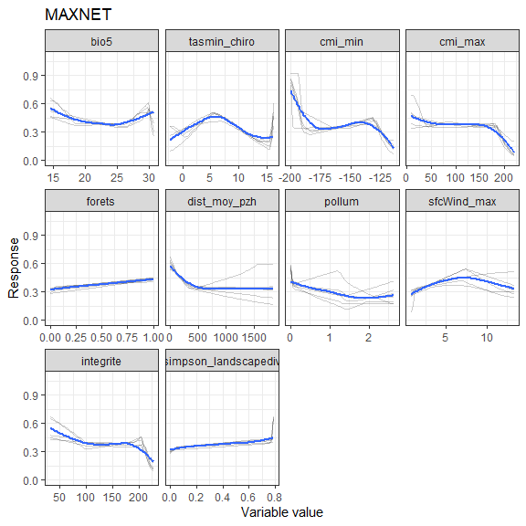

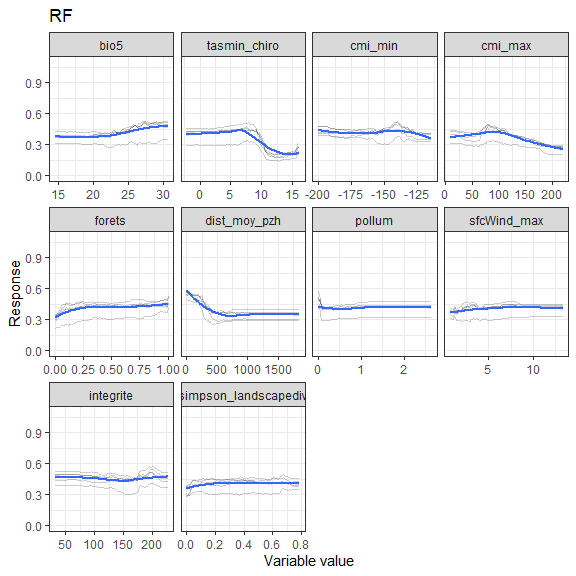

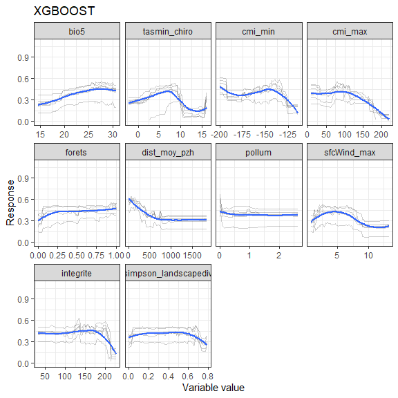

```r
# Variables utilisées pour la calibration
cur_vars <- model_runs@expl.var.names

# Calcul des courbes de réponse
resp <- bm_PlotResponseCurves(bm.out = model_runs,
                              fixed.var = "mean",
                              data_species = occurrences,
                              do.plot = FALSE,
                              do.progress = FALSE)$tab
colnames(resp) <- c("Index", "Variable", "Var.value", "Model", "Response")

for (model in c("GLM", "GBM", "GAM", "MARS",
                "MAXNET",
                "RF", "XGBOOST")) {
  p <- ggplot(resp[grep(model, resp$Model), ], aes(x = Var.value, y = Response)) +
  geom_line(alpha = 0.2, aes(group = Model)) +
  stat_smooth() +
  facet_wrap(~ Variable, scales = "free_x") +
  theme_bw() +
  ylim(0, 1.1) +
  xlab("Variable value") +
    ggtitle(model)

  print(p)
}
```

# Cartes

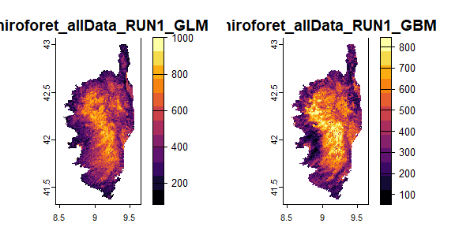

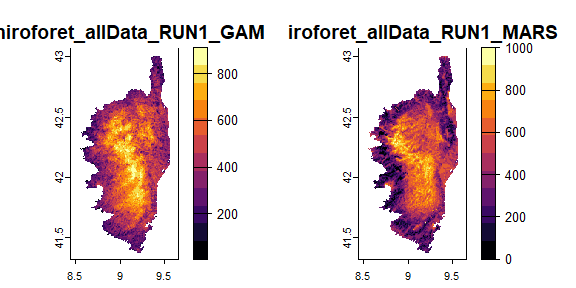

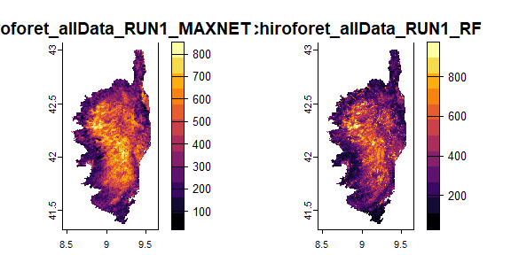

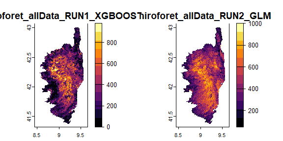

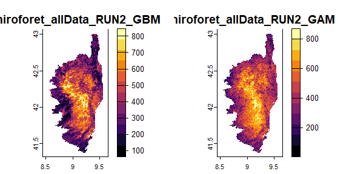

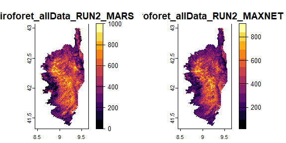

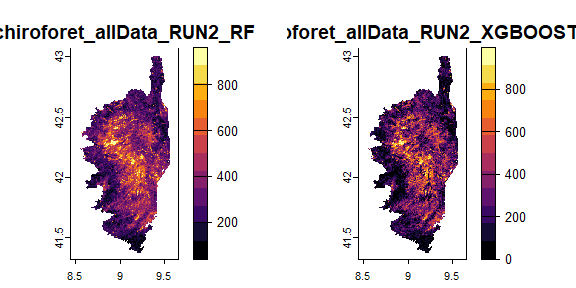

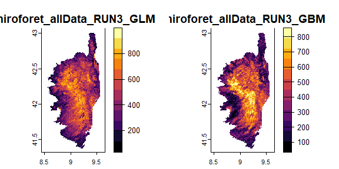

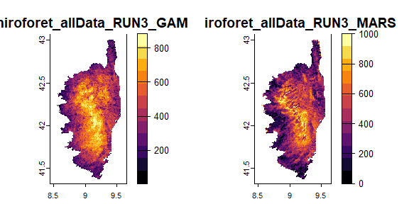

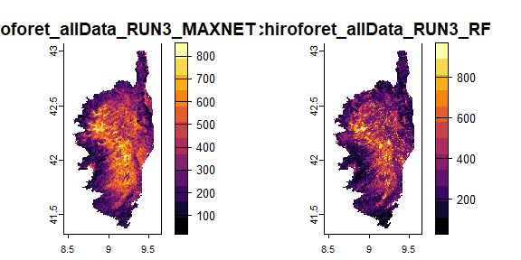

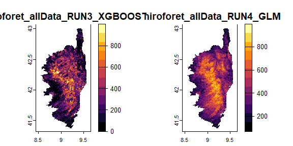

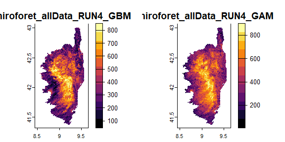

[6 more figures not shown]

```r
# On ne va garder que les modèles qui ont un indice de Boyce suffisamment élevé
models_to_proj <- evals_boyce$full.name[which(evals_boyce$validation >= 0.5)]


projection_runs <- BIOMOD_Projection(
  bm.mod = model_runs, # Modèles calibrés
  proj.name = "corse", # Nom de la projection actuelle
  new.env = env_chiroforet, # Données environnementales sur lesquelles on projette les modèles
  models.chosen = models_to_proj, # Modèles à projeter
  build.clamping.mask = TRUE, # Le clamping mask illustre les zones où les prédictions sont en dehors des valeurs
  # utilisées lors de la calibration
  nb.cpu = 4)

cartes_individuelles <- rast("models/chiroforet/proj_corse/proj_corse_chiroforet.tif")


# Rescaling des projections qui dépassent l'intervalle 0 - 1000
cartes_individuelles[cartes_individuelles < 0] <- 0
cartes_individuelles[cartes_individuelles > 1000] <- 1000

for(i in 1:ceiling(nlyr(cartes_individuelles) / 2)) {
  plot(cartes_individuelles[[(i * 2 - 1):
                               min(nlyr(cartes_individuelles),
                                   (i * 2))]],
       col = viridis::inferno(12))
}
```

# Carte finale

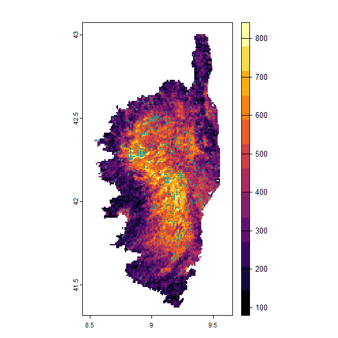

```r
carte_finale <- mean(cartes_individuelles)

plot(carte_finale,
     col = viridis::inferno(12))
points(y ~ x, data = P_points[which(P_points$occurrence == 1), ],
       pch = 16, cex = .4,
       col = "#21908CFF")
```

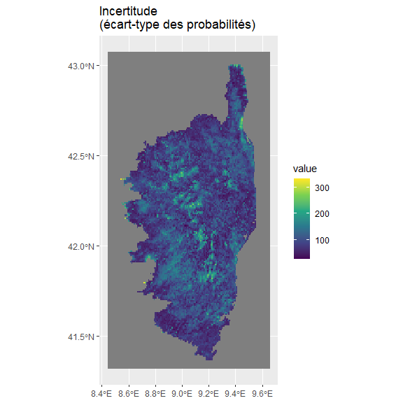

```r
carte_incertitude <- app(cartes_individuelles, sd)
ggplot() +
  geom_spatraster(data = carte_incertitude) +
  scale_fill_continuous(type = "viridis") +
  ggtitle("Incertitude\n(écart-type des probabilités)")
```

## Carte de rendu, essai 1

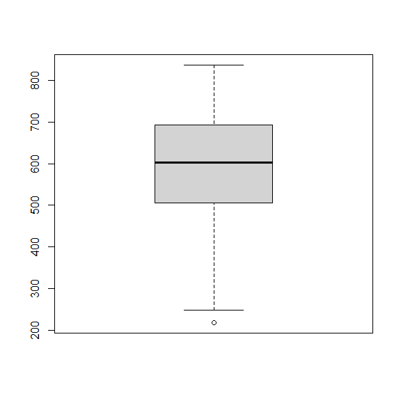

```r
favorabilite_presences <- extract(carte_finale,
                                  P_points[which(P_points$occurrence == 1),
                                           c("x", "y")],
                                  ID = FALSE)
boxplot(favorabilite_presences)
```

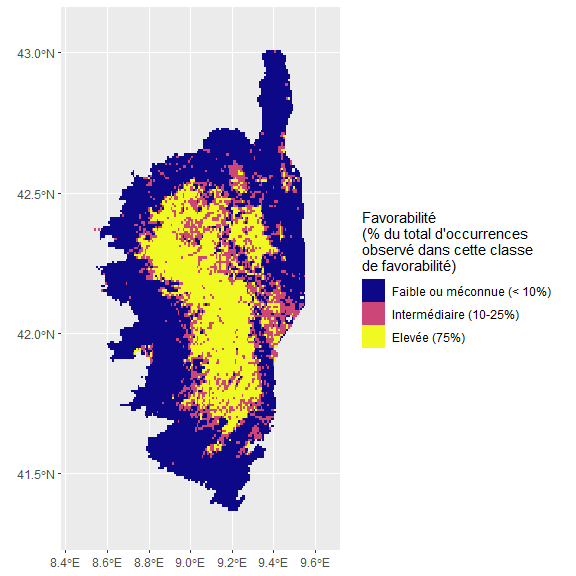

```r
qt_favorabilite <- quantile(favorabilite_presences$mean, probs = c(.10, .25))

carte_indice <- carte_finale
carte_indice[carte_finale < qt_favorabilite["10%"]] <- 0
carte_indice[carte_finale >= qt_favorabilite["10%"] &
               carte_finale < qt_favorabilite["25%"]] <- 1
carte_indice[carte_finale >= qt_favorabilite["25%"]] <- 2

carte_indice <- as.factor(carte_indice)

ggplot() +
  geom_spatraster(data = carte_indice) +
  scale_fill_manual(values = viridis::plasma(3),
                    name = paste0("Favorabilité\n(% du total d'occurrences\n",
                                  "observé dans cette classe\n",
                                  "de favorabilité)"),
                    labels = c("Faible ou méconnue (< 10%)",
                               "Intermédiaire (10-25%)",
                               "Elevée (75%)"),
                    na.translate = F)
```